# Midterm Exam

Ryan Hensley

2023-10-16

**Copyright Kaitlyn Hoffmann, All rights reserved. Not for resale, distribution, or posting to external sites for all content provided.**

# Midterm Exam: 30 points Total

- Good Luck!
- Make sure to review the Coding Policy posted to SAKAI to avoid losing points. Submit the Word Document to SAKAI alongside your Exam (no late work)!

**—————————————————————————————**

# START: Data Types and Structures | Data Cleaning and Manipulaton

- 8 Points

**—————————————————————————————**

## Load: Read the data from occup5.csv creating a new data frame called occup5

```r
#Code: nothing needed this chunk, just run it
occup5<-read.csv("occup5.csv")
```

## Look at the data: Display the first 6 rows of the data frame object occup5

```r
#Code:
head(occup5)
```

```
##   occupID income work educ age hours         satisfaction
## 1       5   65.1 21.7   12  45    50       very satisfied
## 2       5   63.0 20.0   12  44    52       very satisfied
## 3       5   61.8 20.0   12  38    48 moderately satisfied
## 4       5   65.0 19.5   14  55    40       very satisfied
## 5       5   65.3 18.9   12  47    NA moderately satisfied
## 6       5   60.6 18.6   15  38    60       very satisfied
##                 important
## 1             high income
## 2          work enjoyment
## 3 advancement opportunity
## 4          work enjoyment
## 5 advancement opportunity
## 6             high income
```

## NAs: Take a look at the number of NA (blank values), complete the following:

- 1. How many NA values are in the hours column? Code and response.
- 2. What is the average hours (hint: remember if there are NA values you need rm.na=TRUE see cheat sheet) Code and response.
- 3. Change the NA values to the mean average hours **only for the hours Column**
- 4. Remove the column occupID from occup5 (the first column)

```r
#------------------------------------
#Code (a.):
sum(is.na(occup5$hours))
```

```
## [1] 2
```

```r
#Response (a.): 2
#------------------------------------
#Code (b.):
mean(occup5$hours,na.rm=TRUE)
```

```
## [1] 47.21739
```

```r
#Response (b.): 47.21739
#------------------------------------
#Code (c.):
occup5$hours[is.na(occup5$hours)] = 47.21739



#------------------------------------
#Code (d.):
occup5$occupID = NULL
```

## Subset for non-NA: Create a subset (called occup5NoNA) that will remove all remaining rows with a NA value (na.omit) from occup5

- How many rows were removed from occup5 to occup5NoNA? Response.

```r
#------------------------------------
#Code:
occup5NoNA = na.omit(occup5)
nrow(occup5)
```

```
## [1] 25
```

```r
nrow(occup5NoNA)
```

```
## [1] 24
```

```r
#Response: 1
```

## Data Types: Review the data frame occup5NoNA Change the columns/variables to the most fit data type. **Make sure to use occup5NoNA this chunk**

- 1. The data should have the following (total 7 columns): 2 factor, 2 integers (educ and age), 3 numeric.
- 2. Run str(occup5NoNA)

```r
#------------------------------------
#Code (a.):
str(occup5NoNA)
```

```
## 'data.frame':    24 obs. of  7 variables:
##  $ income      : num  65.1 63 61.8 65 65.3 60.6 66 58.3 66.3 63.1 ...
##  $ work        : num  21.7 20 20 19.5 18.9 18.6 18.5 18.3 18.3 18.1 ...
##  $ educ        : int  12 12 12 14 12 15 12 12 14 12 ...
##  $ age         : int  45 44 38 55 47 38 37 37 52 42 ...
##  $ hours       : num  50 52 48 40 47.2 ...
##  $ satisfaction: chr  "very satisfied" "very satisfied" "moderately satisfied" "very satisfied" ...
##  $ important   : chr  "high income" "work enjoyment" "advancement opportunity" "work enjoyment" ...
##  - attr(*, "na.action")= 'omit' Named int 24
##   ..- attr(*, "names")= chr "24"
```

```r
occup5NoNA$satisfaction = as.factor(occup5NoNA$satisfaction)
occup5NoNA$important = as.factor(occup5NoNA$important)



#------------------------------------
#Code (b.):

str(occup5NoNA)
```

```
## 'data.frame':    24 obs. of  7 variables:
##  $ income      : num  65.1 63 61.8 65 65.3 60.6 66 58.3 66.3 63.1 ...
##  $ work        : num  21.7 20 20 19.5 18.9 18.6 18.5 18.3 18.3 18.1 ...
##  $ educ        : int  12 12 12 14 12 15 12 12 14 12 ...
##  $ age         : int  45 44 38 55 47 38 37 37 52 42 ...
##  $ hours       : num  50 52 48 40 47.2 ...
##  $ satisfaction: Factor w/ 3 levels "dissatisfied",..: 3 3 2 3 2 3 2 2 1 2 ...
##  $ important   : Factor w/ 3 levels "advancement opportunity",..: 2 3 1 3 1 2 2 3 3 1 ...
##  - attr(*, "na.action")= 'omit' Named int 24
##   ..- attr(*, "names")= chr "24"
```

**—————————————————————————————**

# END: Data Types and Structures | Data Cleaning and Manipulaton

**—————————————————————————————**

**—————————————————————————————**

# START: Descriptive Analytics

- 6 Points

**—————————————————————————————**

## Load: Read the data from standardtests.csv creating a new data frame called results

```r
#Code: nothing needed this chunk, just run it
results = read.csv("standardtests.csv")
```

## Display the summary stats for results and complete the following:

- 1. Which column has the highest average between A, B, C, D, and E?
- 2. What was the median number of passed exams?

```r
#------------------------------------
#Code:
summary(results)
```

```
##  Institutional_Code     City              Appeared          Passed
##  Min.   :200109     Length:290         Min.   :   3.0   Min.   :  3.0
##  1st Qu.:201512     Class :character   1st Qu.:  61.0   1st Qu.: 35.0
##  Median :201618     Mode  :character   Median : 111.5   Median : 69.0
##  Mean   :242713                        Mean   : 175.7   Mean   :115.7
##  3rd Qu.:303808                        3rd Qu.: 200.8   3rd Qu.:141.8
##  Max.   :307189                        Max.   :1175.0   Max.   :852.0
##  PercentagePassed       A                B                C
##  Min.   : 10.34   Min.   :  0.00   Min.   :  1.00   Min.   :  1.00
##  1st Qu.: 50.23   1st Qu.:  6.00   1st Qu.: 10.00   1st Qu.: 11.25
##  Median : 61.83   Median : 17.50   Median : 22.00   Median : 22.50
##  Mean   : 62.27   Mean   : 42.44   Mean   : 33.79   Mean   : 32.22
##  3rd Qu.: 77.28   3rd Qu.: 44.00   3rd Qu.: 43.00   3rd Qu.: 40.75
##  Max.   :100.00   Max.   :562.00   Max.   :235.00   Max.   :296.00
##        D               E
##  Min.   : 1.00   Min.   :0.00000
##  1st Qu.: 2.00   1st Qu.:0.00000
##  Median : 4.00   Median :0.00000
##  Mean   : 7.19   Mean   :0.07241
##  3rd Qu.: 8.75   3rd Qu.:0.00000
##  Max.   :88.00   Max.   :3.00000
```

```r
#------------------------------------
#Response (a.): A

#Response (b.): 69.0
```

## Display a histogram for the variable passed; main=“Passed Distribution”, col = “orange”

- 1. Based on the result, provide the approximate range (x-axis) of the bin from the histogram with the highest frequency.

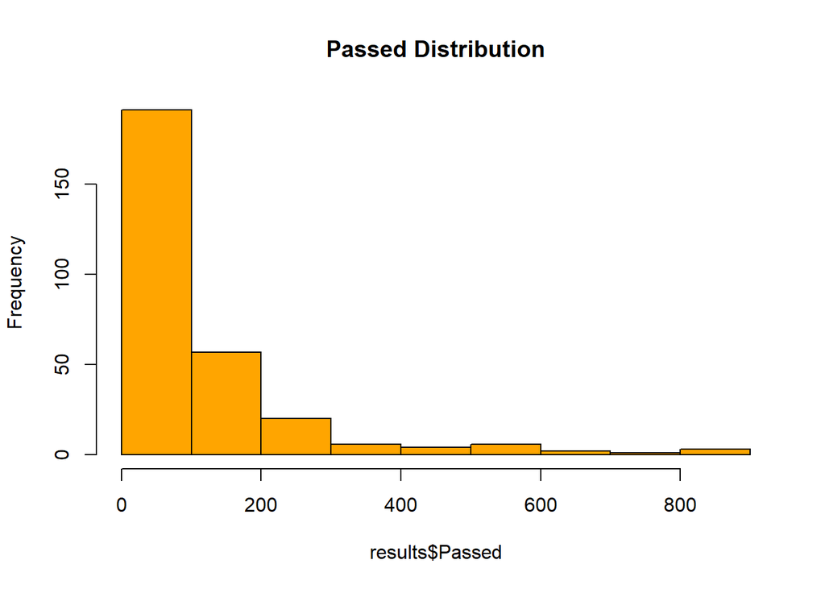

```r
#------------------------------------
#Code:
hist(results$Passed,main = "Passed Distribution", col = "orange")
```

```r
#------------------------------------
#Response (a.): 100
```

## Display the frequency table for city and complete the following:

- 1. How many tests were taken from Carbondale?

```r
#------------------------------------
#Code:
table(results$City)
```

```
##
## Bloomington  Carbondale     Chicago      DeKalb    Elmhurst
##          31          32         102          65          60
```

```r
#------------------------------------
#Response (a.):32
```

## Display/tabulate the average Passed by the City for results.

- 1. What is the average Passed for Chicago? Response.

```r
#------------------------------------
#Code:
tapply(results$Passed,results$City,mean)
```

```
## Bloomington  Carbondale     Chicago      DeKalb    Elmhurst
##     92.3871    102.9062    130.5882    112.4769    112.8500
```

```r
#------------------------------------
#Response (a.):130.5882
```

**—————————————————————————————**

# END: Descriptive Analytics

**—————————————————————————————**

**—————————————————————————————**

# START: Predictive Analytics | Regression

- 14 Points

**—————————————————————————————**

## Load: Read the data from insurance.csv creating a new data frame called insurance

```r
#Code: nothing needed this chunk, just run it
insurance=read.csv("insurance.csv")
```

## Calculate the following correlation coefficients looking to build a model to predict the charges

- insurance (7 columns) looking to predict charges
- 1. Which variable has the highest absolute correlation to charges?

```r
#------------------------------------
#Code:
cor(insurance$charges,insurance[,1:7])
```

```
##            age         sex       bmi   children    smoker     region charges
## [1,] 0.2935438 -0.04498657 0.1950512 0.05738634 0.7866212 0.01778799       1
```

```r
#------------------------------------
#Response (a.): smoker
```

## Complete the following: Regression Model and Summary

- Use a simple regression model to predict charges by using the highest correlated variable from the previous chunk as the independent variable. Call this model as R1
- Display the summary calculations for R1

```r
options(scipen=999)
#------------------------------------------
#Regression Model:
R1 = lm(charges~smoker,data = insurance)

#------------------------------------------
#Summary of Model:
summary(R1)
```

```
##
## Call:
## lm(formula = charges ~ smoker, data = insurance)
##
## Residuals:
##    Min     1Q Median     3Q    Max
## -19250  -5064   -812   3723  31691
##
## Coefficients:
##             Estimate Std. Error t value            Pr(>|t|)
## (Intercept)   8543.4      239.2   35.72 <0.0000000000000002 ***
## smoker       23536.5      533.8   44.10 <0.0000000000000002 ***
## ---
## Signif. codes:  0 '***' 0.001 '**' 0.01 '*' 0.05 '.' 0.1 ' ' 1
##
## Residual standard error: 7407 on 1198 degrees of freedom
## Multiple R-squared:  0.6188, Adjusted R-squared:  0.6185
## F-statistic:  1944 on 1 and 1198 DF,  p-value: < 0.00000000000000022
```

```r
#------------------------------------------
```

## Complete the following: **Answer in chunk as a comment**:

- What is the estimated regression equation?
- What percentage of the total variation in charges is explained by the regression (R2)?
- Is the independent variable significant in predicting the charges at significance level of 0.05? To answer this question, we need to test Ho that H1= 0 against the two-sided alternative. Should the null hypothesis be accepted or rejected at a 0.05 significance level?
- Conceptual Question: Keep it simple, what is the difference of a positive and negative correlation?

```r
#------------------------------------------
#Regression Equation:
#Answer: Y = 8543.4 + 23536.5x


#------------------------------------------
#R2:
##Answer: 0.6188 or 61.88% of the variation is is explained by the independent variable in the model



#------------------------------------------
#Hypothesis Testing:

#Answer p-value: 0.0000000000000002 < 0.05
#Decision/Response: Reject the null hypothesis [that smoker is not significant]; smoker is significant in predicting charges


#------------------------------------------
# Conceptual Question Response: Postive correlation means that as one value goes up the other also goes up. Negative correltaion is as one goes up the other goes down.

#------------------------------------------
```

## Complete the following: Prediction and Confidence Interval

- Calculate the predicted average charges using a value of 1 for the independent variable.
- Construct a 95 percent confidence interval estimate for the mean charges using 1 for the independent variable value. (include correct interpretation)

```r
#------------------------------------------
#Predict Code
8543.4 + (23536.5*1)
```

```
## [1] 32079.9
```

```r
#Answer/Statement: the predicted average charges for a indiviudal with an smoker rate of 1 Is 32079.9 dollars

#------------------------------------------
#Confidence Interval Code

predict(R1, data.frame(smoker=1), interval="confidence")
```

```
##        fit      lwr      upr
## 1 32079.84 31143.69 33015.99
```

```r
#------------------------------------------
#Confidence Interval Interpretation Response/Statement: With 95% confidence, we can say the charges with an smoker value of 1 would have a charges between 31143.69 and 33015.99
#------------------------------------------
```

**—————————————————————————————**

# END: Predictive Analytics | Regression

**—————————————————————————————**

# Knit to HTML

- 2 points overall knit and completion
- Make sure to review the Coding Policy posted to SAKAI to avoid losing points. Submit the Word Document to SAKAI alongside your Exam (no late work)!

**Copyright Kaitlyn Hoffmann, All rights reserved. Not for resale, distribution, or posting to external sites for all content provided.**